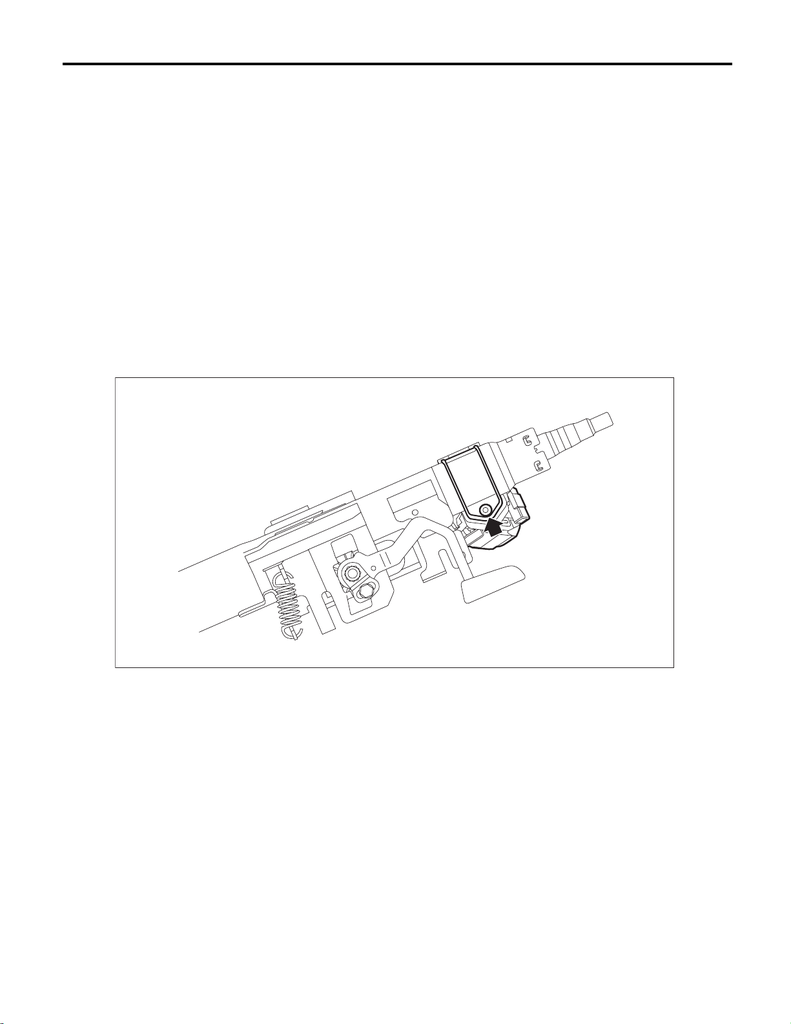

SL-64

Ignition Key Lock

SECURITY AND LOCKS

18.Ignition Key Lock

A: REPLACEMENT

CAUTION:

• Before handling the airbag module, refer to “CAUTION” of “General Description” in “AIRBAG SYS-

TEM”. <Ref. to AB-9, CAUTION, General Description.>

• Do not allow harness and connectors to interfere or get tangled up with other parts.

• If the steering wheel and steering angle sensor (steering roll connector) are removed, perform

“VDC sensor midpoint setting mode” of the VDC. <Ref. to VDC-16, VDC SENSOR MIDPOINT SETTING

MODE, ADJUSTMENT, VDC Control Module and Hydraulic Control Unit (VDCCM&H/U).>

1) Disconnect the ground cable from battery and wait for at least 60 seconds before starting work. <Ref. to

NT-5, BATTERY, NOTE, Note.>

NOTE:

For models other than STI model, disconnect the ground terminal from battery sensor.

2) Remove the column assembly - steering. <Ref. to PS-25, REMOVAL, Steering Column.>

3) Remove the ignition key lock.

(1) Secure the column assembly - steering in a vise.

(2) Use the reverse tap and drill to remove the set bolt and remove the ignition key lock.

4) Install the ignition key lock.

(1) Secure the ignition key lock to the column assembly - steering.

(2) Use new set bolts. Tighten the bolt until the bolt head is broken (bolt head wrenched off).

5) Install the column assembly - steering. <Ref. to PS-28, INSTALLATION, Steering Column.>

6) Connect the battery ground terminal. <Ref. to NT-5, BATTERY, NOTE, Note.>

NOTE:

For models other than STI model, connect the ground terminal to battery sensor.

B: DISASSEMBLY

NOTE:

Refer to “Key Lock Cylinders” for disassembly of the ignition key lock. <Ref. to SL-66, STEERING LOCK, RE-

MOVAL, Key Lock Cylinders.>

SL-01521

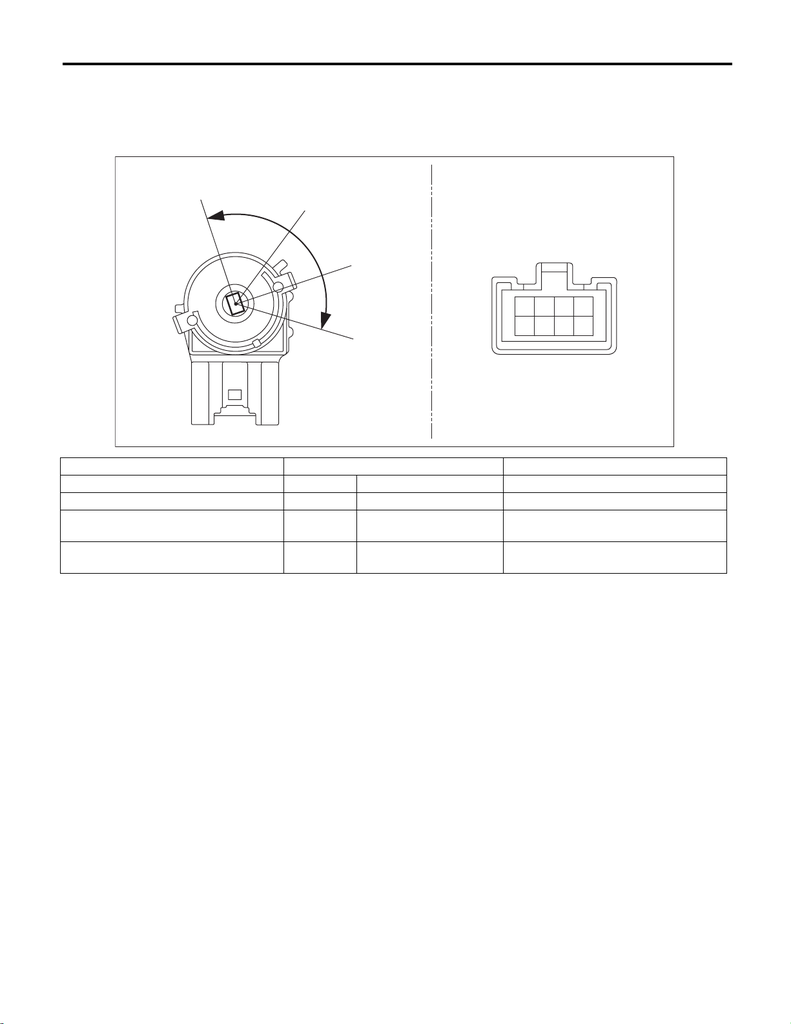

SL-65

Ignition Key Lock

SECURITY AND LOCKS

C: INSPECTION

1) Measure the resistance between connector terminals.

Preparation tool:

Circuit tester

2) Replace the ignition switch assembly if the inspection result is not within the standard.

Terminal No. Inspection conditions Standard

Between all terminals (A) LOCK 1 MΩ or more

2 — 4 (B) ACC Less than 1 Ω

5 — 6

(C) ON Less than 1 Ω

5 — 6 — 7

(D) ST Less than 1 Ω

SL-01522

(A)

(B)

(C)

(D)